# Prediction Assignment

Ngozi Ihemelandu

May 27, 2017

## Load The Data from CSV

```r
filename <- "pml-training.csv"
dataset <- read.csv(filename)
```

## Exploratory Analysis

**Dimensions of the dataset**

```r
dim(dataset)
```

```
## [1] 19622   160
```

**list types for each attribute**

```r
as.data.frame(sapply(dataset,class))
```

```
##                          sapply(dataset, class)
## X                                       integer
## user_name                                factor
## raw_timestamp_part_1                    integer
## raw_timestamp_part_2                    integer
## cvtd_timestamp                           factor
## new_window                               factor
## num_window                              integer
## roll_belt                               numeric
## pitch_belt                              numeric
## yaw_belt                                numeric
## total_accel_belt                        integer
## kurtosis_roll_belt                       factor
## kurtosis_picth_belt                      factor
## kurtosis_yaw_belt                        factor
## skewness_roll_belt                       factor
## skewness_roll_belt.1                     factor
## skewness_yaw_belt                        factor
## max_roll_belt                           numeric
## max_picth_belt                          integer
## max_yaw_belt                             factor
## min_roll_belt                           numeric
## min_pitch_belt                          integer
## min_yaw_belt                             factor
## amplitude_roll_belt                     numeric
## amplitude_pitch_belt                    integer
## amplitude_yaw_belt                       factor
## var_total_accel_belt                    numeric
## avg_roll_belt                           numeric
## stddev_roll_belt                        numeric
## var_roll_belt                           numeric
## avg_pitch_belt                          numeric
## stddev_pitch_belt                       numeric
## var_pitch_belt                          numeric
## avg_yaw_belt                            numeric
## stddev_yaw_belt                         numeric
## var_yaw_belt                            numeric
## gyros_belt_x                            numeric
## gyros_belt_y                            numeric
## gyros_belt_z                            numeric
```

[output cut: 106 more lines]

```
## stddev_pitch_forearm                    numeric
## var_pitch_forearm                       numeric
## avg_yaw_forearm                         numeric
## stddev_yaw_forearm                      numeric
## var_yaw_forearm                         numeric
## gyros_forearm_x                         numeric
## gyros_forearm_y                         numeric
## gyros_forearm_z                         numeric
## accel_forearm_x                         integer
## accel_forearm_y                         integer
## accel_forearm_z                         integer
## magnet_forearm_x                        integer
## magnet_forearm_y                        numeric
## magnet_forearm_z                        numeric
## classe                                   factor
```

**Peek at the structure of the Data**

```r
str(dataset)
```

```
## 'data.frame':    19622 obs. of  160 variables:
##  $ X                       : int  1 2 3 4 5 6 7 8 9 10 ...
##  $ user_name               : Factor w/ 6 levels "adelmo","carlitos",..: 2 2 2 2 2 2 2 2 2 2 ...
##  $ raw_timestamp_part_1    : int  1323084231 1323084231 1323084231 1323084232 1323084232 1323084232 1323084232 1323084232 1323084232 1323084232 ...
##  $ raw_timestamp_part_2    : int  788290 808298 820366 120339 196328 304277 368296 440390 484323 484434 ...
##  $ cvtd_timestamp          : Factor w/ 20 levels "02/12/2011 13:32",..: 9 9 9 9 9 9 9 9 9 9 ...
##  $ new_window              : Factor w/ 2 levels "no","yes": 1 1 1 1 1 1 1 1 1 1 ...
##  $ num_window              : int  11 11 11 12 12 12 12 12 12 12 ...
##  $ roll_belt               : num  1.41 1.41 1.42 1.48 1.48 1.45 1.42 1.42 1.43 1.45 ...
##  $ pitch_belt              : num  8.07 8.07 8.07 8.05 8.07 8.06 8.09 8.13 8.16 8.17 ...
##  $ yaw_belt                : num  -94.4 -94.4 -94.4 -94.4 -94.4 -94.4 -94.4 -94.4 -94.4 -94.4 ...
##  $ total_accel_belt        : int  3 3 3 3 3 3 3 3 3 3 ...
##  $ kurtosis_roll_belt      : Factor w/ 397 levels "","-0.016850",..: 1 1 1 1 1 1 1 1 1 1 ...
##  $ kurtosis_picth_belt     : Factor w/ 317 levels "","-0.021887",..: 1 1 1 1 1 1 1 1 1 1 ...
##  $ kurtosis_yaw_belt       : Factor w/ 2 levels "","#DIV/0!": 1 1 1 1 1 1 1 1 1 1 ...
```

[output cut: 86 more lines]

**Levels of the Class**

```r
levels(dataset$classe)
```

```
## [1] "A" "B" "C" "D" "E"
```

**Class Distribution**

```r
percentage <- prop.table(table(dataset$classe)) * 100
cbind(freq=table(dataset$classe), percentage=percentage)
```

```
##   freq percentage
## A 5580   28.43747
## B 3797   19.35073
## C 3422   17.43961
## D 3216   16.38977
## E 3607   18.38243
```

**Visualize the class distribution of the Dataset**

We would use a Histogram to plot the density of the distribution of the target variable - Classe for each of the six young health participants

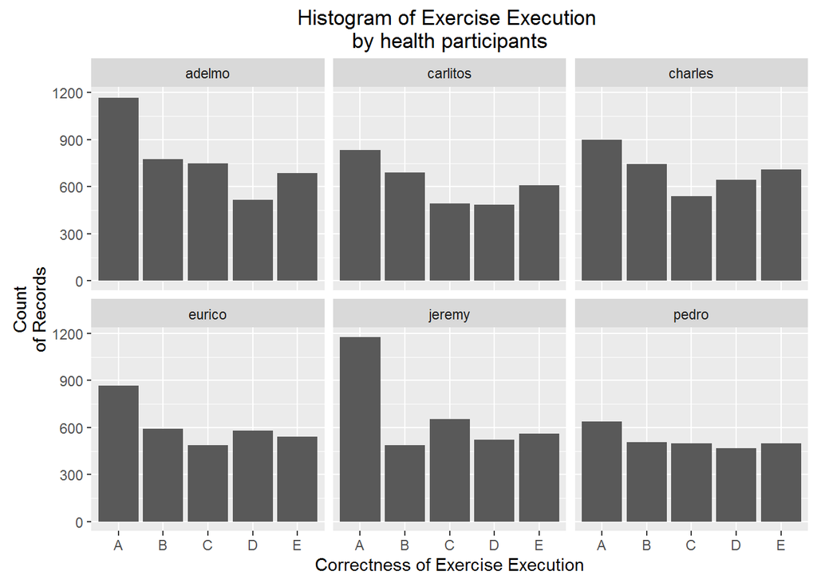

## Clean data set

Remove attributes in which more than 97% of the cases are missing values

```r
dataset <- dataset[which(apply(is.na(dataset),2,sum) < (0.97 * nrow(dataset)))]
```

Remove attributes where more than 97% of the cases contains values such as ‘#DIV/0!’ and are empty

```r
dataset <- dataset[which(apply(dataset,2,function(cl)sum(cl== "" | cl == "#DIV/0!")) < (0.97 * nrow(dataset)))]
```

## Evaluate Some Algorithms

Given that selecting a machine learning algorithm is a process of trial and error We would evaluate 4 different algorithms. To ensure that the evaluation of each algorithm is performed using exactly the same data splits, we would set the random number seed. This also ensures the results are directly comparable. We would use repeated 10-fold cross-validation to choose the tuning parameters for the models.

*Determination of Tuning Parameters* We would choose tuning parameters using resampling of 3 repeats of 10-fold cross-validation. The numerical optimal parameter value would be choosen as the final tuning parameter by the train function.

*prepare training scheme*

```r
control <- trainControl(method="repeatedcv", number=10, repeats=3)
```

*Train the CART (Classification and Regression Trees) model*

*Train the KNN (k-nearest neighbors) model*

*Train the SVM (Support Vector Machine) model*

*Train the RF (Random Forest) model*

**Between Model Comparisons** To compare these models based on their cross-validation statistics, the resamples function will be used. Since the random number seed was initialized prior to running each of the models, paired accuracy measurements exist for each data set.

```r
results <- resamples(list(CART=modelCART, KNN=modelknn, SVM=modelSvm, RF=modelRF))
```

**Summarize the distributions**

```r
summary(results)
```

```
##
## Call:
## summary.resamples(object = results)
##
## Models: CART, KNN, SVM, RF
## Number of resamples: 30
##
## Accuracy
##        Min. 1st Qu. Median   Mean 3rd Qu.   Max. NA's
## CART 0.6609  0.6617 0.8357 0.7720  0.8360 0.8364    0
## KNN  0.9786  0.9824 0.9847 0.9841  0.9852 0.9883    0
## SVM  0.9913  0.9954 0.9962 0.9961  0.9969 0.9995    0
## RF   0.9995  0.9996 1.0000 0.9999  1.0000 1.0000    0
##
## Kappa
##        Min. 1st Qu. Median   Mean 3rd Qu.   Max. NA's
## CART 0.5685  0.5695 0.7917 0.7104  0.7921 0.7926    0
## KNN  0.9729  0.9778 0.9807 0.9798  0.9813 0.9852    0
## SVM  0.9891  0.9942 0.9952 0.9951  0.9961 0.9994    0
## RF   0.9994  0.9995 1.0000 0.9998  1.0000 1.0000    0
```

**Select Best Model**

The summary indicates that the performance distributions are very similiar across all modules except for the CART module. The objective for this project is prediction accuracy on a new set of data, hence We would select the random forest model based on the numerical optimal value of the mean.

## Tune selected model - Random Forest

**Tune parameter candidates**

```r
modelRF$results
```

```
##   mtry  Accuracy     Kappa   AccuracySD      KappaSD
## 1    2 0.9969422 0.9961323 0.0015258022 0.0019298351
## 2   41 0.9998641 0.9998281 0.0002292294 0.0002899463
## 3   81 0.9997622 0.9996992 0.0002910935 0.0003681825
```

**Selected tune parameter**

```r
modelRF$bestTune
```

```
##   mtry
## 2   41
```

**Train selected Model** The data set is split into a train and a test set. It is a good idea to favor simpler models over more complex ones. Hence, choosing the tuning parameters based on the numerically optimal value may lead to a model that is overly complicated and leads to overfitting. To get a simpler model, we would reset the value of the tune parameter(mtry) to 2 and retrain the model.

**generalization error rate (out-of-sample error rate)**

```r
eval.Table = table(predictedClasses,testing$classe)
eval.Table
```

```
##
## predictedClasses    A    B    C    D    E
##                A 1394    1    0    0    0
##                B    1  947    2    0    0
##                C    0    1  853    6    0
##                D    0    0    0  798    4
##                E    0    0    0    0  897
```

```r
errorRate = (sum(eval.Table[row(eval.Table) != col(eval.Table)]) / sum(eval.Table)) * 100
errorRate
```

```
## [1] 0.3058728
```

The generalization error rate is acceptable, so we would retrain the model using the complete dataset with final value for the mtry parameter = 2

```r
rfGrid <-  expand.grid(mtry = c(2))
modelRF <- train(classe~., data=dataset, method="rf", trControl=control, tuneGrid=rfGrid, verboseIter = TRUE)
```

## Make Predictions for the 20 test cases using the selected best model

**Preprocess the test dataset**

```r
filename <- "pml-testing.csv"
validation <- read.csv(filename)
#Remove attributes in which more than 97% of the cases are missing values
validation <- validation[which(apply(is.na(validation),2,sum) < (0.97 * nrow(validation)))]

#Remove attributes where more than 97% of the cases contains values such as '#DIV/0!' and are empty
validation <- validation[which(apply(validation,2,function(cl)sum(cl== "" | cl == "#DIV/0!")) < (0.97 * nrow(validation)))]

#Ensure that the factor variables in the training set and the test set have the same levels
levels(validation$new_window) <- levels(dataset$new_window)
levels(validation$cvtd_timestamp) <- levels(dataset$cvtd_timestamp)
```

**Predict the new samples with the trained model**

```r
predictedClasses <- predict(modelRF,validation)
predictedClasses
```

```
##  [1] B A B A A E D B A A B C B A E E A B A B
## Levels: A B C D E
```